# Deskriptive Analyse

## Employee Churn

Wahrscheinlichkeit der Mitarbeiterfluktuation im BASF Service Hub Berlin

Das BASF Service Hub Berlin ist ein Shared Service Center. Seit 2005 erbringt es Dienstleistungen für Gruppengesellschaften der BASF sowie dem Mutterkonzern, der BASF SE. Die BASF ist nach Umsatz das global führende Chemie-Unternehmen mit circa 115.000 Mitarbeitern weltweit. Die angebotenen Dienstleistungen umfassen Aktivitäten in den Bereichen Personalwesen, internes und externes Rechnungswesen, Einkauf, Supply Chain. Zudem bestehen kleinere Teams, die an digitalen Lösungen in der Landwirtschaft arbeiten oder im Feld der Produktsicherheit tätig sind.

Als Service Hub ist die Fluktuation, die Mitarbeiterabwanderung, höher als an den Produktionsstandorten der BASF und liegt im Durchschnitt bei 12-13% jährlich. Dies hat zur Folge, dass stetig rekrutiert werden muss, was einen Aufwand für die Recrutierungsabteilung und die Manager darstellt, die neue Kandidaten finden müssen. Zudem stellt das Onboarding einen zeitlichen Aufwand für die Teams dar und bis eine neue Arbeitskraft vollumfänglich eingearbeitet ist, muss das Tagesgeschäft von den Kollegen:innen weiterhin gestemmt werden.

Um die Fluktuationsrate zu senken, können Manager frühzeitig Maßnahmen einleiten. Dazu zählen beispielsweise Weiterbildungsangebote, Beförderungen, Job-Rotation oder -Enlargement.

Dass die Wahrscheinlichkeit, dass eine Arbeitskraft das Unternehmen verlassen wird hoch ist, müssen die Manager erkennen. Dies ist jedoch in der Regel eine subjektive Einschätzung.

“Data to Dialouge” - Mittels datengestützter Analysen soll eine zusätzliche Sicht auf die mögliche Fluktuation der Arbeitskräfte gelegt werden. Die aus den Daten gewonnenen Erkenntnisse können die Führungskräfte ihren eigenen Wahrnehmungen gegenüberstellen und abwägen, ob sie mit der Arbeitskraft ins Gespräch gehen und möglicherweise Maßnahmen zum Halten der Person einleiten.

Das Ziel ist es demnach, vorherzusagen, wie wahrscheinlich es ist, dass eine Arbeitskraft zu einem Zeitpunkt das Unternehmen verlassen wird. Diese Informationen können dann in die bereits bestehende Reportinglandschaft (Dashboards) eingebettet werden.

Im Rahmen der Arbeit betrachtete Abgänge sind dabei: Kündigung (von Mitarbeitenden oder Arbeitgeber veranlasst), Aufhebungsverträge (Einigungen das Arbeitsverhältnis vorzeitig zu beenden entweder von Mitarbeitenden oder Arbeitgeber veranlasst), Kündigung in der Probezeit und keine Verlängerung befristeter Arbeitsverhältnisse. Letzteres könnte in der Verfeinerung aus dem Modell entfernt werden. Es ist aufgrund der Bemühung genügend Datenpunkte zu erhalten im ersten Schritt nicht entfernt worden.

Für die Datengrundlage sind eine Reihe an Tabellen aus dem SAP Data Warehouse System im Einsatz. Orientiert wird sich dabei an Phasen, die eine Arbeitskraft im Zuge der Tätigkeit für ein Unternehmen durchläuft. Besonderer Fokus liegt dabei auf den Informationen über die Arbeitskraft zu Beginn der Arbeitstätigkeit und dem Zeitpunkt der letzten Aktivität sowie der Entwicklung. Im Detail werden im Weiteren die Merkmale einzeln beschrieben und analysiert, bei Bedarf klassiert (bei vielen Merkmalsausprägungen qualitativer Merkmale). Die Abgänge seit Januar 2016 bis Oktober 2021 sowie die derzeit aktiven Mitarbeitenden werden in dieser Arbeit betrachtet.

Zur Vorhersage, ob eine Arbeitskraft wahrscheinlich das Unternehmen verlässt, kommen Algorithmen des überwachten maschinellen Lernens zum Einsatz. Es handelt sich um eine Klassifizierung zwischen zwei Klassen. Neben einem Entscheidungsbaum und Tree-Ensambles (Boosting, Bagging, Einsatz von XGBoost) wird die logistische Regression eingesetzt. Im dritten Modell soll die Vorhersage mittels einer Support Vector Maschine oder einem Naive-Bayes-Ansatz durchgeführt werden.

Die Ergebnisse der unterschiedlichen Modelle werden mittels einer Confusion-Matrix miteinander verglichen. Zusätzlich zur Accuracy soll die Balanced Accuracy untersucht werden.

Um die einzelne Modelle der Realität anzupassen soll mit einer Kostenfunktion optimiert werden, welche Falsch-Positive-Werte und Falsch-Negative-Werte unterschiedlich bestraft. Falsch-Negative-Werte (Arbeitskraft verlässt das Unternehmen, aber Modell hat als nicht-riskant klassifiziert) sorgen für Kosten in der Rekrutierung von neuem Personal und verursachen eine erhöhte Belastung für die Teams. Falsch-Positive-Werte (Arbeitskraft plant Unternehmen nicht zu verlassen, aber Modell hat als riskant klassifiziert) führen zu Kosten durch Aufwand für den Manager und die besagte Arbeitskraft, da diese in den Austausch gehen. Zusätzlich kann es zu möglicherweise vermeidbaren Kosten kommen, die im Zuge des Versuchs die Arbeitskraft zu halten, entstehen (Weiterbildung, Gehaltserhöhung). Diese Kosten jedoch zu verallgemeinern, führt zu ungenauen und potenziell falschen Ergebnissen. Zudem ist für eine genaue Schätzung ein hoher Grad an Verständnis in dem Spezialbereich nötig. Dafür ist der Austausch mit den Experten der lokalen Personalabteilung des BASF Service Hubs Berlin geplant.

### Aufgabenstellung

Deskriptive Analyse der Daten: Was beschreiben die Daten, was sind die Datentypen und Wertebereiche, fehlen Daten, gibt es falsche Werte, gibt es Korrelationen zwischen Merkmalen (Features, Spalten)? Benutzen Sie Visualisierungen, wenn es sinnvoll erscheint. Was können wir aus dieser deskriptiven Analyse über das Problem lernen?

### Set-Up

Zu erst laden wir die benötigten Bibliotheken. Die Daten werden anschließend aus einer .xlsx-Datei geladen. Anschließend wandeln wir die Zahlenwerte in das Format Numeric um und die Datumwerte in das Format Datum.

```r
library(readxl)
library(writexl)
library(ggplot2)
library(tidyr)
library(stringr)
library(lubridate)
library(mltools)
library(data.table)
df <- read_xlsx("20211209_raw_dataset.xlsx")

#Years in Numerisch umwandeln
#all Chars in numeric
  #Years of Service Berlin
data_chars_as_num <- df

YearsOfService_BASFBerlin <- df[3]
data_chars_as_num[ ,  "YearsOfService_BASFBerlin"] <-
  as.data.frame(apply(data_chars_as_num[ , "YearsOfService_BASFBerlin"], 2, as.numeric))
  #Years Service all
YearsOfService_BASFall <- df[8]
data_chars_as_num[ ,  "YearsOfService_BASFall"] <-
  as.data.frame(apply(data_chars_as_num[ , "YearsOfService_BASFall"], 2, as.numeric))
df[3] <- data_chars_as_num[3]
df[8] <- data_chars_as_num[8]


df$`start_Calendar Year/Month` <- as.Date(df$`start_Calendar Year/Month`, "%d.%M.%y")
df$`Date of Birth` <- as.Date(df$`Date of Birth`, '%d.%M.%y')
df$`Last_Development_Calendar Year/Month` <- as.Date(df$`Last_Development_Calendar Year/Month`, '%d.%M.%y')
df$`LastActive_Calendar Year/Month` <- as.Date(df$`LastActive_Calendar Year/Month`, '%d.%M.%y')
```

### Bereiniegen der Grunddaten und erzeugen neuer wichtiger Features

Auf Grund der damaliegen Umstellung des Systems ist das Startdatum von 158 Mitarbeitern nicht bekannt. Diese entfernen wir aus unserem Datensatz, da wir für diese Mitarbeiter keine Anstellungsdauer berechnen können.

Folgend berechnen wir die Anstellungsdauer in Monaten, das Alter und die Zeit zwischen letztem Arbeitstag und letzter Beförderung der Mitarbeiter und legen diese jeweils in einer neuen Spalte ab. Die Spalten ‘YearsOfService_BASfall’ ‘YearsOfService_BASFBerlin’, ‘Last_Development_Calendar Year/Month’ und ‘Date of Birth’ werden gelöscht, da wir diese durch ‘month Of Service’, ‘Months Since Last Development’ und ‘age’.

```r
df <- df %>% drop_na('start_Calendar Year/Month')
sum(is.na(df$`start_Calendar Year/Month`))
```

```
## [1] 0
```

```r
start <- df$`start_Calendar Year/Month`
end <- df$`LastActive_Calendar Year/Month`


df$`Month Of Service` <- round(difftime(end, start, units = "days")/30)
df$`Month Of Service` <- as.numeric(df$`Month Of Service`)
# Age
df$Age <- round(difftime(end, df$`Date of Birth`, units = "days") /365)
df$Age <- as.numeric(df$Age)
# Time since last development
df$'Months Since Last Development' <- round(difftime(end, df$`Last_Development_Calendar Year/Month`, units = "days")/30)
df$`Months Since Last Development` <- as.numeric(df$`Months Since Last Development`)

df$YearsOfService_BASFBerlin <- NULL
df$YearsOfService_BASFall <- NULL
df$`Last_Development_Calendar Year/Month` <- NULL
df$`Date of Birth` <- NULL
```

### EmployeeChurned

Dies ist das Ziel-Merkmal und beschreibt, ob die Person das Unternehmen verlassen hat (1) oder noch aktiv ist (0).

```r
unique(df$EmployeeChurned)
```

```
## [1] "0" "1"
```

```r
summary(df$EmployeeChurned)
```

```
##    Length     Class      Mode
##      3869 character character
```

```r
sum(is.na(df$EmployeeChurned))
```

```
## [1] 0
```

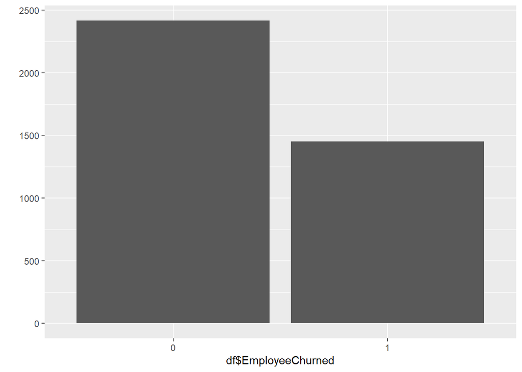

```r
qplot(df$EmployeeChurned)
```

### Gender

Dieses Merkmal beschreibt das Geschlecht der Person.

```r
df$Gender <- replace(df$Gender,df$Gender== "Male","0")
df$Gender <- replace(df$Gender,df$Gender== "Female","1")

unique(df$Gender)
```

```
## [1] "1" "0"
```

```r
summary(df$Gender)
```

```
##    Length     Class      Mode
##      3869 character character
```

```r
sum(is.na(df$Gender))
```

```
## [1] 0
```

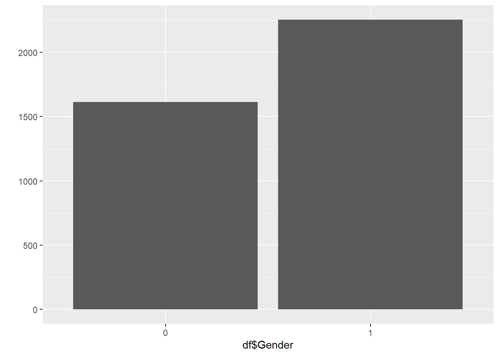

```r
qplot(df$Gender)
```

### Nationality

Dieses Merkmal beschreibt die Nationalität der Person.

```r
# todo: Gruppieren nach DE, EU, NotEU
unique(df$Nationality)
```

```
##   [1] "German"          "Peruvian"        "Lithuanian"      "Finnish"
##   [5] "Spanish"         "Italian"         "Mexican"         "Belgian"
##   [9] "Israeli"         "French"          "Dutch"           "Guatemalan"
##  [13] "Argentinian"     "Brazilian"       "Bulgarian"       "Danish"
##  [17] "Hungarian"       "Portuguese"      "Polish"          "Vietnamese"
##  [21] "Colombian"       "Russian"         "Ukrainian"       "Algerian"
##  [25] "Chinese"         "Senegalese"      "Swedish"         "Indonesian"
##  [29] "South African"   "Cypriot"         "Slovak"          "Indian"
##  [33] "British"         "Swiss"           "Austrian"        "Estonian"
##  [37] "Turkish"         "Azerbaijani"     "Venezuelan"      "Rumanian"
##  [41] "Zimbabwean"      "Panamanian"      "Cameroonian"     "Greek"
##  [45] "Pakistani"       "Tunisian"        "Kazakh"          "Kyrgyzstani"
##  [49] "Burkinabe"       "Singaporean"     "Nicaraguan"      "Serbian"
##  [53] "American"        "Slovenian"       "Moroccan"        "Australian"
##  [57] "Syrian"          "Croatian"        "Ghanian"         "Uzbekistani"
##  [61] "Irish"           "Iranian"         "Malaysian"       "Salvadoran"
##  [65] "Japanese"        "Czech"           "Canadian"        "Lebanese"
##  [69] "Belarusian"      "Jordanian"       "Norwegian"       "Filipino"
##  [73] "Uruguayan"       "Albanian"        "Yemeni"          "Mozambican"
##  [77] "Bangladeshi"     "Egyptian"        "Latvian"         "Kenyan"
##  [81] "Bosnian"         "Chilean"         "Sudanese"        "Togolese"
##  [85] "Ethiopian"       "Korean"          "Not assigned"    "Macedonian"
##  [89] "Honduran"        "Nepalese"        "Nigerian"        "Ecuadorian"
##  [93] "Armenian"        "Bolivian"        "Georgian"        "Minor Outl.Isl."
##  [97] "Luxembourgian"   "Moldovan"        "Mongolian"       "Palestine"
## [101] "Afghan"          "XK"              "Madagascan"      "Thai"
## [105] "Ugandan"         "Tajikistani"     "Congolese"
```

```r
summary(df$Nationality)
```

```
##    Length     Class      Mode
##      3869 character character
```

```r
sum(is.na(df$Nationality))
```

```
## [1] 0
```

```r
df$Nationality <- NULL
```

### Nationality_Classification

Dieses Merkmal beschreibt die Nationalität der Person klassiert in “German”, “EU” und “Other”.

```r
unique(df$Nationality_Classification)
```

```
## [1] "German" "Other"  "EU"
```

```r
summary(df$Nationality_Classification)
```

```
##    Length     Class      Mode
##      3869 character character
```

```r
sum(is.na(df$Nationality_Classification))
```

```
## [1] 0
```

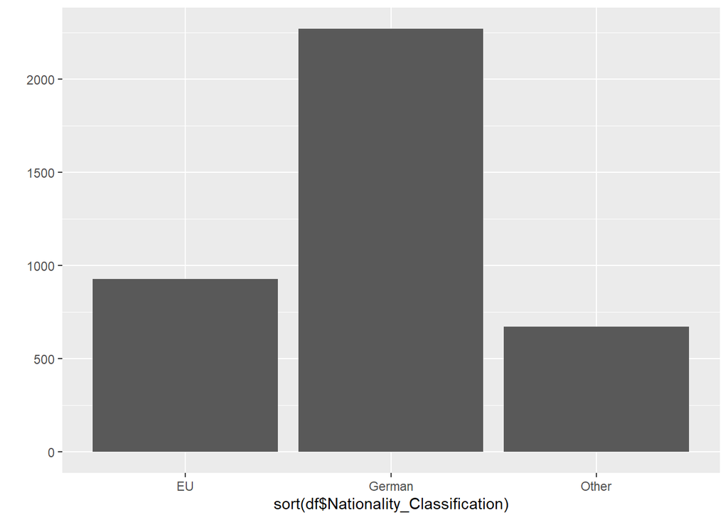

```r
qplot(sort(df$Nationality_Classification))
```

```r
df$Nationality_Classification <- as.factor(df$Nationality_Classification)
```

### YearsOfService_BASFBerlin

Dieses Merkmal beschreibt, wie lange die Person im Unternehmen bisher tätig war in Jahren (nur Berliner Standort). Dabei wird aufgerundet. Das Symbol “#” gilt für eine Unternehmenszugehörigkeit unter einem Jahr. Aus diesem Grund wird die Unternehmenszugehörigkeit manuell berechnet aus dem Startdatum und dem letzten Aktivitätsdatum. Zusätzlich wird neben den Jahren auch die Monate angegeben.

```r
unique(df$YearsOfService_BASFBerlin)
```

[output not shown]

```r
summary(df$YearsOfService_BASFBerlin)
```

```
## Length  Class   Mode
##      0   NULL   NULL
```

```r
sum(is.na(df$YearsOfService_BASFBerlin))
```

```
## [1] 0
```

```r
#qplot(df$YearsOfService_BASFBerlin)
```

### Position text

Dieses Merkmal beschreibt in welcher Position die Person tätig ist bzw. zuletzt war. Es kann auch als Planstelle bezeichnet werden. Aufgrund der Menge an Merkmalsausprägungen werden diese im weiteren Verlauf in Clustern zusammengefasst (Paybands).

```r
unique(df$`Position text`)
```

```
##  [1] "Expert"
##  [2] "Teamspecialist"
##  [3] "Executive Specialist"
##  [4] "Manager"
##  [5] "Officer"
##  [6] "Head of Project"
##  [7] "Senior Expert"
##  [8] "Senior Project Manager"
##  [9] "Specialist"
## [10] "Project Manager"
## [11] "Senior Officer"
## [12] "Senior Advisor"
## [13] "Accountant"
## [14] "Head of Department"
## [15] "Senior Accountant"
```

[output cut: 38 more lines]

```r
summary(df$`Position text`)
```

```
##    Length     Class      Mode
##      3869 character character
```

```r
sum(is.na(df$`Position text`))
```

```
## [1] 0
```

```r
df$`Position text` <- NULL
```

### Role

Dieses Merkmal beschreibt die Rolle der Person. Aufgrund der Menge an Merkmalsausprägungen und der weniger verbreiteten Anwendung im Unternehmenskontext wird dieses Merkmal entfernt. Die Informationen sind allerdings in vergleichbarer Art im Paybands-Merkmal enthalten.

```r
unique(df$Role)
```

```
##  [1] "Specialist"               "Teamleader"
##  [3] "Employee Representatives" "Manager"
##  [5] "Officer"                  "Head of"
##  [7] "Employee Representat"     "Apprentices Interns"
##  [9] "Not assigned"             "Grouplevel 4"
## [11] "Grouplevel 3"
```

```r
summary(df$Role)
```

```
##    Length     Class      Mode
##      3869 character character
```

```r
sum(is.na(df$Role))
```

```
## [1] 0
```

```r
# qplot(df$Role)

df$Role <- NULL
```

### Part Time Mark

Dieses Merkmal beschreibt, ob die Person zum Zeitpunkt der letzten Aktivität in Teilzeit tätig ist/war (1) oder nicht (0).

```r
unique(df$`Part Time Mark`)
```

```
## [1] "yes" "no"
```

```r
summary(df$`Part Time Mark`)
```

```
##    Length     Class      Mode
##      3869 character character
```

```r
sum(is.na(df$`Part Time Mark`))
```

```
## [1] 0
```

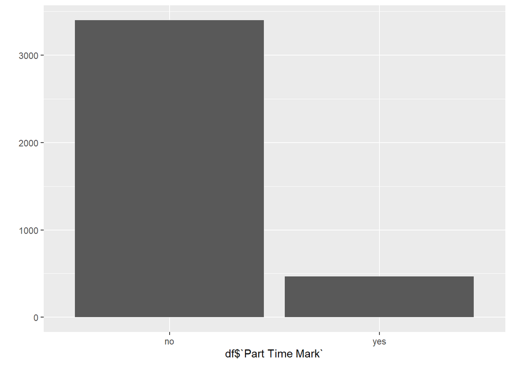

```r
qplot(df$`Part Time Mark`)
```

```r
df$`Part Time Mark` <- replace(df$`Part Time Mark`,df$`Part Time Mark`== "no","0")
df$`Part Time Mark` <- replace(df$`Part Time Mark`,df$`Part Time Mark`== "yes","1")
```

### Global contract type

Dieses Merkmal beschreibt die Vertragsart der Person zum Zeitpunkt der letzten Aktivität. 0 - permanent staff (unbefristet) 1 - temporary personnel (befristet)

```r
df$`Global contract type` <- replace(df$`Global contract type`,df$`Global contract type`== "apprentice","1")

unique(df$`Global contract type`)
```

```
## [1] "permanent staff"     "temporary personnel" "1"
```

```r
summary(df$`Global contract type`)
```

```
##    Length     Class      Mode
##      3869 character character
```

```r
sum(is.na(df$`Global contract type`))
```

```
## [1] 0
```

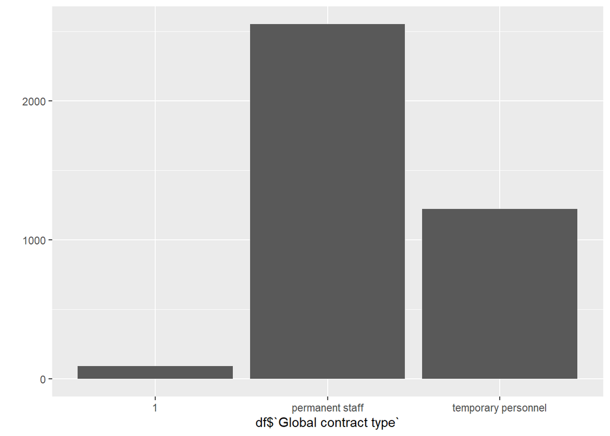

```r
qplot(df$`Global contract type`)
```

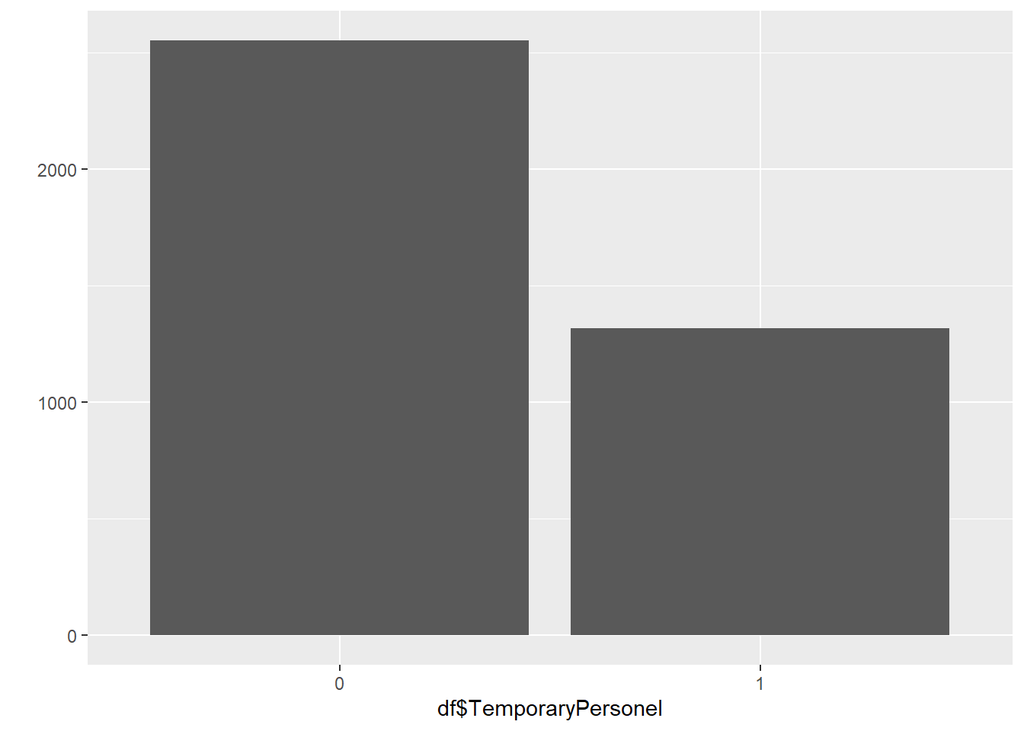

```r
df$`Global contract type` <- replace(df$`Global contract type`,df$`Global contract type`== "permanent staff","0")
df$`Global contract type` <- replace(df$`Global contract type`,df$`Global contract type`== "temporary personnel","1")

colnames(df)[which(names(df) == "Global contract type")] <- "TemporaryPersonel"
qplot(df$`TemporaryPersonel`)
```

### YearsOfService_BASFall

Dieses Merkmal beschreibt, wie lange die Person im Unternehmen bisher tätig war.

```r
unique(df$YearsOfService_BASFall)
```

[output not shown]

```r
summary(df$YearsOfService_BASFall)
```

```
## Length  Class   Mode
##      0   NULL   NULL
```

```r
sum(is.na(df$YearsOfService_BASFall))
```

```
## [1] 0
```

```r
#qplot(df$YearsOfService_BASFall)
```

### Employee Subgroup text

Dieses Merkmal beschreibt welcher Mitarbeitergruppe die Person zugeordnet ist/war.

Aufgrund der Verteilung ist eine Einstufung nur in die Gruppen “exempt” (außertarfilich beschäftigt) und “non exempt” (tariflich beschäftigt). 0 - “exempt” umfasst: “exempt”, “exempt higher level”, “senior executive” 1 - “non exempt”: “non-exempt (white)”, “working student whit”, “apprentice”

```r
unique(df$`Employee Subgroup text`)
```

```
## [1] "exempt"               "non-exempt (white)"   "exempt higher level"
## [4] "working student whit" "apprentice"           "senior executive"
```

```r
summary(df$`Employee Subgroup text`)
```

```
##    Length     Class      Mode
##      3869 character character
```

```r
sum(is.na(df$`Employee Subgroup text`))
```

```
## [1] 0
```

```r
# qplot(df$`Employee Subgroup text`)

df$`Employee Subgoup text clustered` <- df$`Employee Subgroup text`
df$`Employee Subgoup text clustered` <- replace(df$`Employee Subgoup text clustered`,df$`Employee Subgoup text clustered`== "exempt","0")
df$`Employee Subgoup text clustered` <- replace(df$`Employee Subgoup text clustered`,df$`Employee Subgoup text clustered`== "exempt higher level","0")
df$`Employee Subgoup text clustered` <- replace(df$`Employee Subgoup text clustered`,df$`Employee Subgoup text clustered`== "senior executive","0")
df$`Employee Subgoup text clustered` <- replace(df$`Employee Subgoup text clustered`,df$`Employee Subgoup text clustered`== "non-exempt (white)","1")
df$`Employee Subgoup text clustered` <- replace(df$`Employee Subgoup text clustered`,df$`Employee Subgoup text clustered`== "working student whit","1")
df$`Employee Subgoup text clustered` <- replace(df$`Employee Subgoup text clustered`,df$`Employee Subgoup text clustered`== "apprentice","1")

colnames(df)[which(names(df) == "Employee Subgoup text clustered")] <- "NonExempt"

unique(df$'NonExempt')
```

```
## [1] "0" "1"
```

```r
summary(df$'NonExempt')
```

```
##    Length     Class      Mode
##      3869 character character
```

```r
sum(is.na(df$'NonExempt'))
```

```
## [1] 0
```

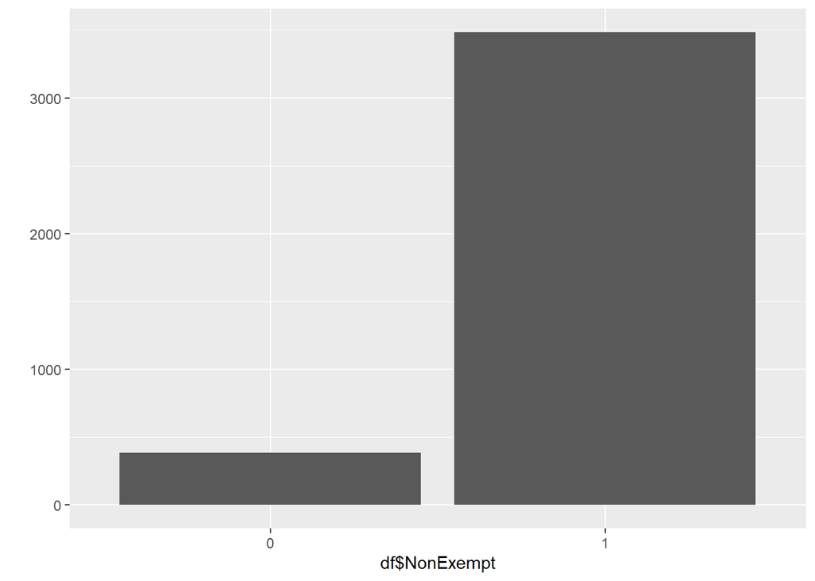

```r
qplot(df$'NonExempt')
```

```r
df$`Employee Subgroup text` <- NULL
```

### Cost Center long

Dieses Merkmal beschreibt die Kostenstelle inclusive der Zuordnung der Region und dem Unternehmen.

```r
# unique(df$`Cost Center long`)
summary(df$`Cost Center long`)
```

```
##    Length     Class      Mode
##      3869 character character
```

```r
sum(is.na(df$`Cost Center long`))
```

```
## [1] 0
```

```r
df$`Cost Center long` <-  NULL
```

### Cost Center text

Dieses Merkmal beschreibt den Namen der Kostenstelle.

```r
# unique(df$`Cost Center text`)
summary(df$`Cost Center text`)
```

```
##    Length     Class      Mode
##      3869 character character
```

```r
sum(is.na(df$`Cost Center text`))
```

```
## [1] 0
```

```r
df$`Cost Center text` <- NULL
```

### LastActive_Calendar Year/Montht

Dieses Merkmal beschreibt, wann die Person das letzte Mal aktiv war.

```r
# unique(df$`LastActive_Calendar Year/Month`)
summary(df$`LastActive_Calendar Year/Month`)
```

```
##         Min.      1st Qu.       Median         Mean      3rd Qu.         Max.
## "2015-12-01" "2020-02-01" "2021-10-01" "2020-10-20" "2021-10-01" "2021-10-01"
```

```r
sum(is.na(df$`LastActive_Calendar Year/Month`))
```

```
## [1] 0
```

### TEC

Dieses Merkmal beschreibt ob die Person einen vollumfänglichen Vertrag mit dem Standort Berlin hat. Beispielsweise haben Praktikanten oder Leasingkräfte keinen solchen Vertrag. Im Fokus der Analyse sollten deswegen die TEC-Kräfte stehen, da diese auch nur im Personal-Reporting berücksichtigt werden.

```r
unique(df$TEC)
```

```
## [1] 1
```

```r
summary(df$TEC)
```

```
##    Min. 1st Qu.  Median    Mean 3rd Qu.    Max.
##       1       1       1       1       1       1
```

```r
sum(is.na(df$TEC))
```

```
## [1] 0
```

```r
df$TEC <- NULL
```

### Stelle (SAP)

Dieses Merkmal beschreibt die Position der Person, wie sie in SAP (Quellsystem) gepflegt ist.

```r
unique(df$`Stelle (SAP)`)
```

```
##  [1] "Expert"
##  [2] "Teamspecialist"
##  [3] "Executive Specialist"
##  [4] "Manager"
##  [5] "Officer"
##  [6] "Head of Project"
##  [7] "Senior Expert"
##  [8] "Senior Project Manager"
##  [9] "Specialist"
## [10] "Project Manager"
## [11] "Senior Officer"
## [12] "Senior Advisor"
## [13] "Accountant"
## [14] "Head of Department"
## [15] "Senior Accountant"
```

[output cut: 34 more lines]

```r
summary(df$`Stelle (SAP)`)
```

```
##    Length     Class      Mode
##      3869 character character
```

```r
sum(is.na(df$`Stelle (SAP)`))
```

```
## [1] 6
```

```r
# qplot(df$`Stelle (SAP)`)

df$`Stelle (SAP)` <- NULL
```

### In Dashboard

Dieses Merkmal beschreibt die Position der Person in Clustern. Dabei wird sich an den Gehaltsbändern orientiert. Payband “A” ist dabei das niedrigste und Payband “H” das höchste.

```r
unique(df$`In Dashboard`)
```

```
##  [1] "Project Manager / Expert"
##  [2] "Teamspecialist / Knowledge Coordinator"
##  [3] "Executive Accountant/Advisor/Buyer/Specialist/Assistant"
##  [4] "Manager"
##  [5] "Officer / Team Assistant"
##  [6] "Head of"
##  [7] "Senior Expert / Senior Project Manager / Senior Manager/ Finance Manager"
##  [8] "Accountant/Advisor/Buyer/Specialist und Senior Officer"
##  [9] "Senior Accountant/Advisor/Buyer/Specialist"
## [10] "Assistant"
## [11] "Student Trainee / Trainee"
## [12] "Apprentice / Apprentice BA"
## [13] "Senior Executive"
## [14] NA
```

```r
summary(df$`In Dashboard`)
```

```
##    Length     Class      Mode
##      3869 character character
```

```r
sum(is.na(df$`In Dashboard`))
```

```
## [1] 6
```

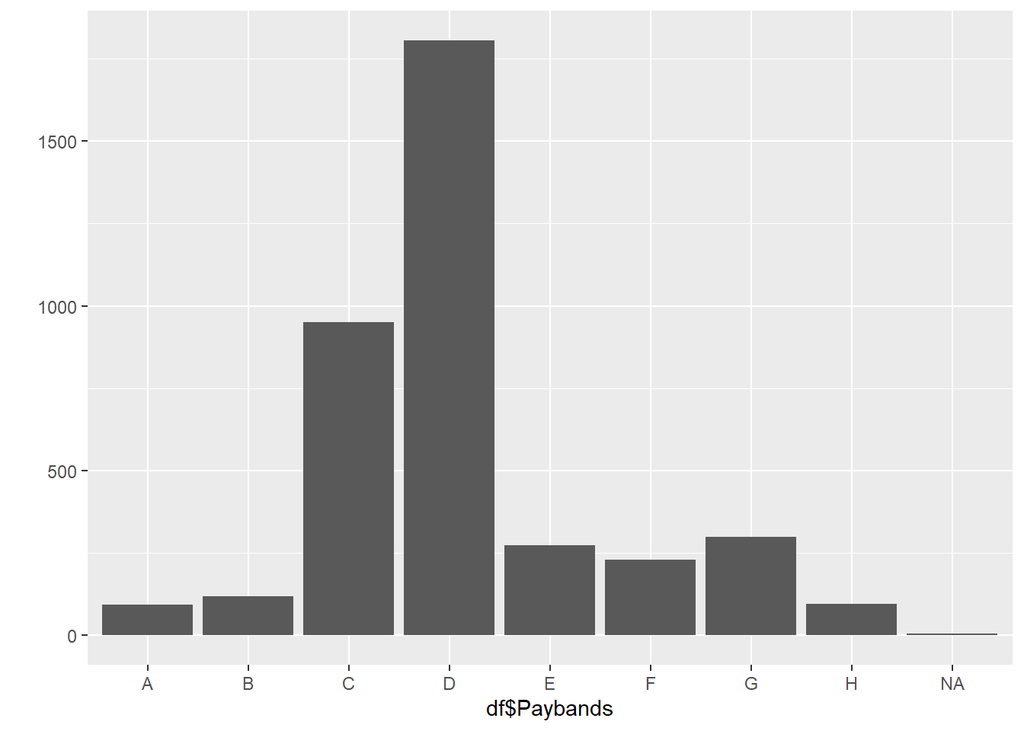

```r
# qplot(df$`In Dashboard`)

df$`Paybands`<- df$`In Dashboard`
df$`Paybands` <- replace(df$`Paybands`,df$`Paybands`== "Apprentice / Apprentice BA","A")
df$`Paybands` <- replace(df$`Paybands`,df$`Paybands`== "Student Trainee / Trainee" ,"B")
df$`Paybands` <- replace(df$`Paybands`,df$`Paybands`== "Assistant" ,"C")
df$`Paybands` <- replace(df$`Paybands`,df$`Paybands`== "Officer / Team Assistant","C")
df$`Paybands` <- replace(df$`Paybands`,df$`Paybands`== "Accountant/Advisor/Buyer/Specialist und Senior Officer","D")
df$`Paybands` <- replace(df$`Paybands`,df$`Paybands`== "Senior Accountant/Advisor/Buyer/Specialist","D")
df$`Paybands` <- replace(df$`Paybands`,df$`Paybands`== "Executive Accountant/Advisor/Buyer/Specialist/Assistant","E")
df$`Paybands` <- replace(df$`Paybands`,df$`Paybands`== "Teamspecialist / Knowledge Coordinator" ,"F")
df$`Paybands` <- replace(df$`Paybands`,df$`Paybands`== "Manager","G")
df$`Paybands` <- replace(df$`Paybands`,df$`Paybands`== "Manager","G")
df$`Paybands` <- replace(df$`Paybands`,df$`Paybands`== "Project Manager / Expert","G")
df$`Paybands` <- replace(df$`Paybands`,df$`Paybands`== "Head of","H")
df$`Paybands` <- replace(df$`Paybands`,df$`Paybands`== "Senior Expert / Senior Project Manager / Senior Manager/ Finance Manager","H")
df$`Paybands` <- replace(df$`Paybands`,df$`Paybands`== "Senior Executive","H")

df$`Paybands` <- as.factor(df$`Paybands`)
qplot(df$Paybands)
```

```r
df$`In Dashboard` <- NULL
```

### Paybands

Dieses Merkmal beschreibt die Position der Person in Klustern. Dabei wird sich an den Gehaltsbändern orientiert.

```r
unique(df$`Paybands`)
```

```
## [1] G    F    E    C    H    D    B    A    <NA>
## Levels: A B C D E F G H
```

```r
summary(df$`Paybands`)
```

```
##    A    B    C    D    E    F    G    H NA's
##   93  118  951 1805  273  230  298   95    6
```

```r
sum(is.na(df$`Paybands`))
```

```
## [1] 6
```

```r
# qplot(df$`Paybands`)
```

### Name on Dashboard

Dieses Merkmal beschreibt die Position der Person in Klustern. Dabei wird sich an den Gehaltsbändern orientiert und in Oberbegriffe untergliedert Da der Wertebereich noch relativ hoch ist, könnte eine zusätzliche Gruppierung, die sich noch näher an die Gehaltsbänder anpasst, verfolgt werden.

```r
unique(df$`Name on Dashboard`)
```

```
##  [1] "PM/Expert"                "TS/KCS"
##  [3] "Executive Specialist"     "Manager"
##  [5] "Officer/Team Assistant"   "Head of"
##  [7] "Sr. Expert/PM/Manager"    "Specialist & Sr. Officer"
##  [9] "Sr. Specialist"           "Assistant"
## [11] "Student Trainee"          "Apprentice"
## [13] "Senior Executive"         NA
```

```r
summary(df$`Name on Dashboard`)
```

```
##    Length     Class      Mode
##      3869 character character
```

```r
#sum(is.na(df$`Name on Dashboard`))

df$`Name on Dashboard` <- NULL
```

### Classification

Dieses Merkmal beschreibt die Einteilung in Mitarbeitergruppen in der Logik des Reportings am Standort Berlin. Die “Employee Subgroup” sollte bevorzugt eingesetzt werden in einer vergleichsweisen Gruppierung.

```r
unique(df$Classification)
```

```
## [1] "Exempt"     "Non-Exempt" "Student"    NA
```

```r
summary(df$Classification)
```

```
##    Length     Class      Mode
##      3869 character character
```

```r
sum(is.na(df$Classification))
```

```
## [1] 6
```

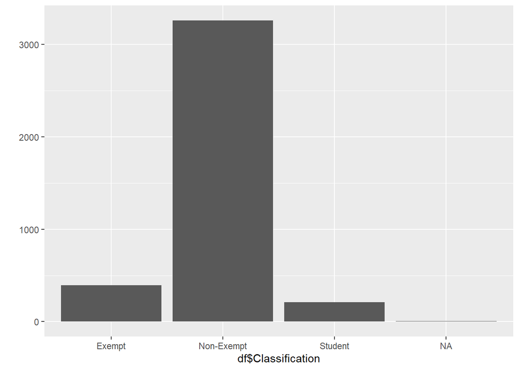

```r
qplot(df$Classification)
```

```r
df$Classification <- NULL
```

### Last_Development_Calendar Year/Month

Dieses Merkmal beschreibt, wann sich die Person das zum letzten Mal horizontal oder vertikal oder von tariflich beschäftigt zu außertariflich beschäftigt entwickelt hat. Leere Werte deuten darauf hin, dass sich die Person noch nicht entwickelt hat. In solchen Fällen ist das Startdatum der Person als Berechnungsgrundlage zu wählen.

```r
# todo: in Date umwandeln, falls leer mit Start-Datum ersetzen - in Monaten
summary(df$'Last_Development_Calendar Year/Month')
```

```
## Length  Class   Mode
##      0   NULL   NULL
```

```r
sum(is.na(df$'Last_Development_Calendar Year/Month'))
```

```
## [1] 0
```

### development to exempt

Dieses Merkmal beschreibt die Entwicklung einer Person von tariflich beschäftigt zu außer-tariflich beschäftigt (1) oder nicht (0). Diese Entwicklung ist oft im Zusammenhang mit der Beförderung in eine Experten- oder Managerfunktion zu beobachten. Die zweifache Entwicklung zum außertariflichen Beschäftigungsverhältnis kann auf einen Eingabefehler zurück- geführt werden und wird in diesem Schritt in eine “1” umgewandelt.

```r
df$`development to exempt` <- replace(df$`development to exempt`,df$`development to exempt`== "2","1")
unique(df$'development to exempt')
```

```
## [1] "1" "0"
```

```r
summary(df$'development to exempt')
```

```
##    Length     Class      Mode
##      3869 character character
```

```r
sum(is.na(df$'development to exempt'))
```

```
## [1] 0
```

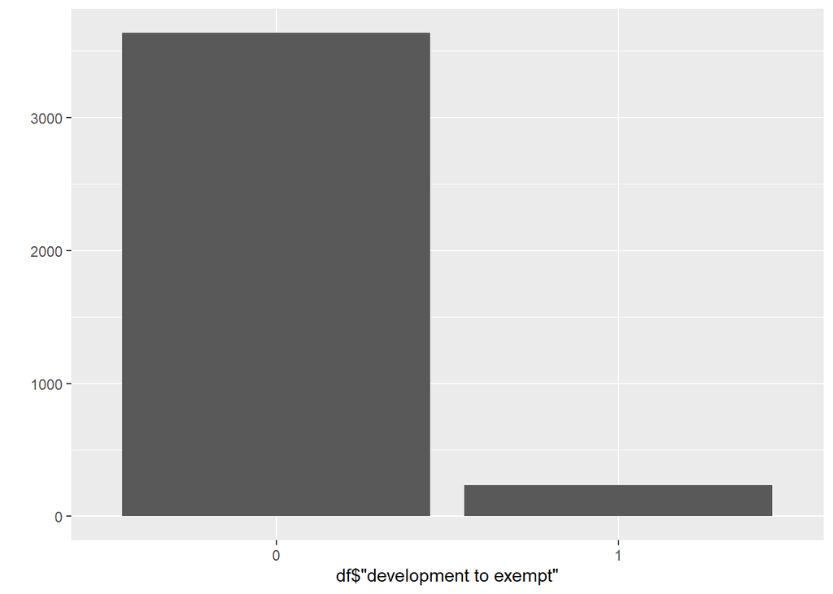

```r
qplot(df$'development to exempt')
```

### Vertical_Horizontal_Developments

Dieser Wert sagt aus, wie oft der Mitarbeiter vertikal und horizontal im Unternhemen befördert wurde.

```r
unique(df$Vertical_Horizontal_Developments)
```

```
## [1] 3 1 0 2 4 5 6 7 8
```

```r
summary(df$Vertical_Horizontal_Developments)
```

```
##    Min. 1st Qu.  Median    Mean 3rd Qu.    Max.
##  0.0000  0.0000  0.0000  0.6614  1.0000  8.0000
```

```r
sum(is.na(df$Vertical_Horizontal_Developments))
```

```
## [1] 0
```

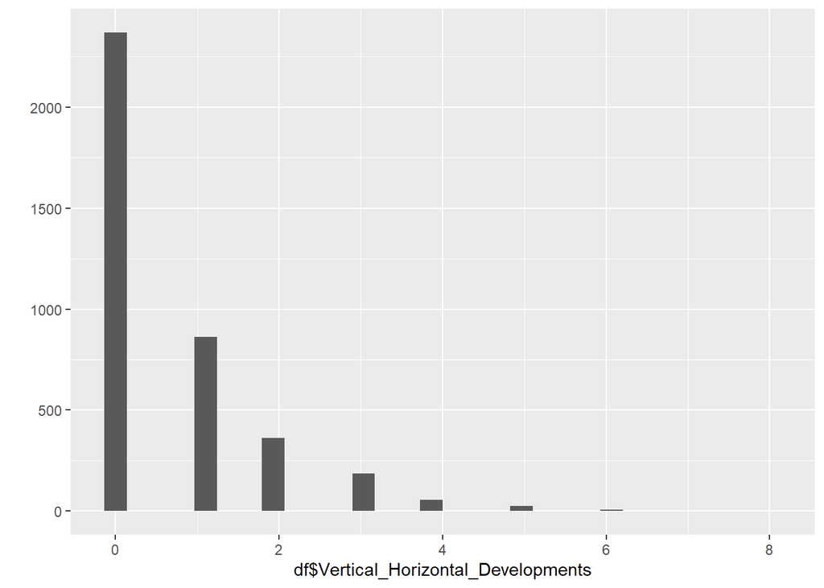

```r
qplot(df$Vertical_Horizontal_Developments)
```

```r
df$Vertical_Horizontal_Developments <- replace(df$Vertical_Horizontal_Developments,df$Vertical_Horizontal_Developments== "1","1-2")
df$Vertical_Horizontal_Developments <- replace(df$Vertical_Horizontal_Developments,df$Vertical_Horizontal_Developments== "2","1-2")
df$Vertical_Horizontal_Developments <- replace(df$Vertical_Horizontal_Developments,df$Vertical_Horizontal_Developments== "3",">= 3")
df$Vertical_Horizontal_Developments <- replace(df$Vertical_Horizontal_Developments,df$Vertical_Horizontal_Developments== "4",">= 3")
df$Vertical_Horizontal_Developments <- replace(df$Vertical_Horizontal_Developments,df$Vertical_Horizontal_Developments== "5",">= 3")
df$Vertical_Horizontal_Developments <- replace(df$Vertical_Horizontal_Developments,df$Vertical_Horizontal_Developments== "6",">= 3")
df$Vertical_Horizontal_Developments <- replace(df$Vertical_Horizontal_Developments,df$Vertical_Horizontal_Developments== "7",">= 3")
df$Vertical_Horizontal_Developments <- replace(df$Vertical_Horizontal_Developments,df$Vertical_Horizontal_Developments== "8",">= 3")

df$Vertical_Horizontal_Developments <- as.factor(df$Vertical_Horizontal_Developments)
```

### start_Calendar Year/Month

Ist das Datum an dem der Mitarbeiter im Unternhemen angefangen hat.

```r
# unique(df$'start_Calendar Year/Month')
summary(df$'start_Calendar Year/Month')
```

```
##         Min.      1st Qu.       Median         Mean      3rd Qu.         Max.
## "2006-10-01" "2015-08-01" "2018-04-01" "2017-04-05" "2020-06-01" "2021-10-01"
```

```r
sum(is.na(df$'start_Calendar Year/Month'))
```

```
## [1] 0
```

```r
#hier nach Jahren und eventuell Monaten splitten, dann könnte man ne Abhängigkeit zeigen, dass z.B. Menschen die Monat Januar anfangen schneller aussteigen als #im März :D


#Monat
```

### start_contract type

Hat der Mitarbeiter bei Anstellung einen temporären oder dauerhaften Vertrag bekommen? Dieses Merkmal beschreibt die Vertragsart der Person zum Start im Unternehmen. Diese unterscheidet sich leicht zur Ausprägung “Global contract type”.

```r
unique(df$'start_contract type')
```

```
## [1] "permanent staff"     "temporary personnel" "apprentice"
```

```r
summary(df$'start_contract type')
```

```
##    Length     Class      Mode
##      3869 character character
```

```r
sum(is.na(df$'start_contract type'))
```

```
## [1] 0
```

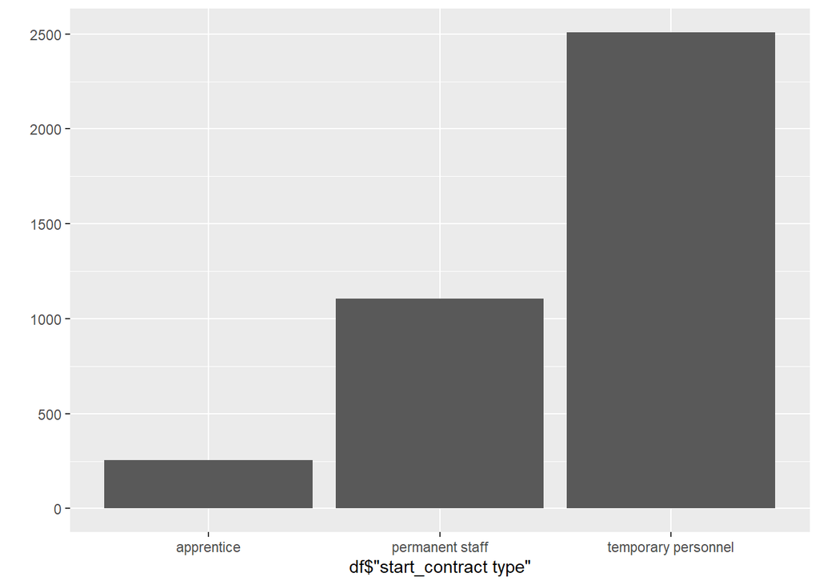

```r
qplot(df$'start_contract type')
```

```r
df$'start_contract type' <- as.factor(df$'start_contract type')
```

### start_Part time mark

Zu Beginn der Anstellung in Teilzeit angestellt. Dieses Merkmal beschreibt, ob die Person zum Zeitpunkt der ersten Aktivität in Teilzeit tätig ist/war (1) oder nicht (0).

```r
unique(df$'start_Part time mark')
```

```
## [1] "no"  "yes"
```

```r
summary(df$'start_Part time mark')
```

```
##    Length     Class      Mode
##      3869 character character
```

```r
sum(is.na(df$'start_Part time mark'))
```

```
## [1] 0
```

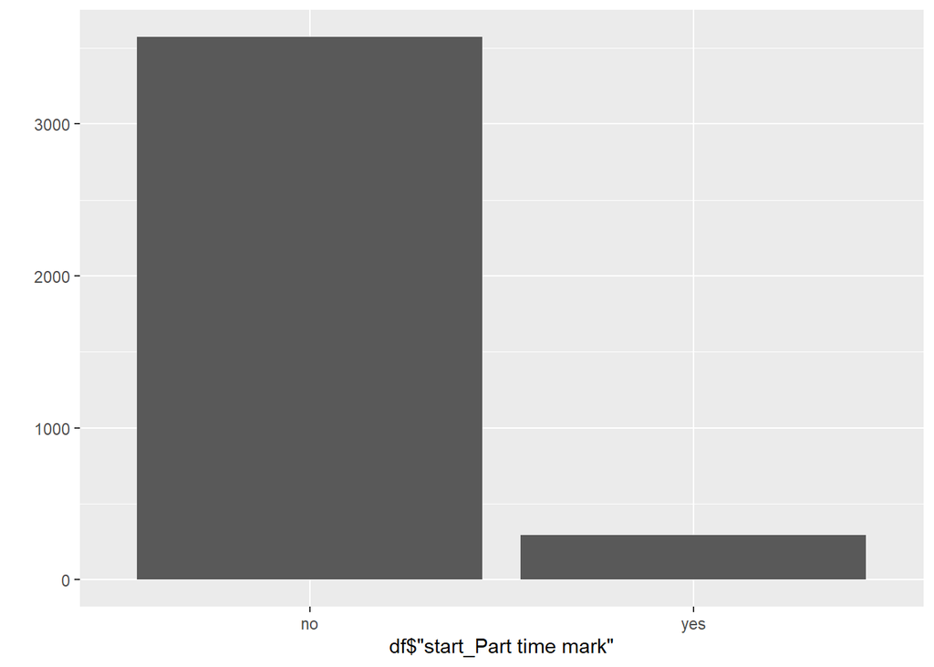

```r
qplot(df$'start_Part time mark')
```

```r
df$'start_Part time mark' <- replace(df$'start_Part time mark',df$'start_Part time mark'== "no","0")
df$'start_Part time mark' <- replace(df$'start_Part time mark',df$'start_Part time mark'== "yes","1")
```

### start_employee subgroup detail

Beschreibt Vertragsart bei Anstellung Aufgrund der Verteilung ist eine Einstufung nur in die Gruppen “exempt” (außertarfilich beschäftigt) und “non exempt” (tariflich beschäftigt). 0 - “exempt” umfasst: “exempt”, “exempt higher level”, “senior executive” 1 - “non exempt”: “non-exempt (white)”, “working student whit”, “apprentice”

```r
unique(df$'start_employee subgroup detail')
```

```
## [1] "non-exempt (white)"   "exempt"               "working student whit"
## [4] "exempt higher level"  "apprentice"           "senior executive"
```

```r
summary(df$'start_employee subgroup detail')
```

```
##    Length     Class      Mode
##      3869 character character
```

```r
sum(is.na(df$'start_employee subgroup detail'))
```

```
## [1] 0
```

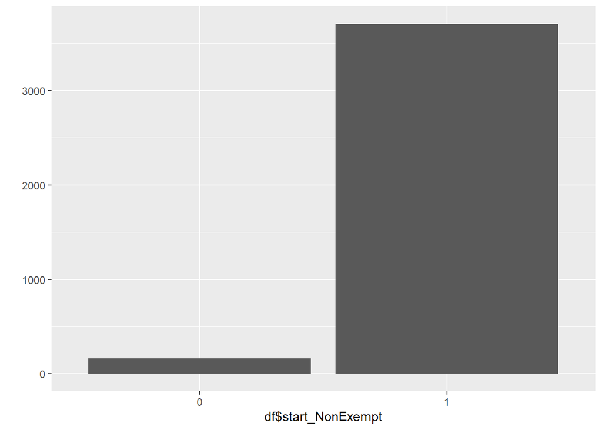

```r
#cluster in exampt and non exempt
df$'start_employee subgroup detail clustered' <- df$'start_employee subgroup detail'
df$'start_employee subgroup detail clustered' <- replace(df$'start_employee subgroup detail clustered',df$'start_employee subgroup detail clustered'== "exempt","0")
df$'start_employee subgroup detail clustered' <- replace(df$'start_employee subgroup detail clustered',df$'start_employee subgroup detail clustered'== "exempt higher level","0")
df$'start_employee subgroup detail clustered' <- replace(df$'start_employee subgroup detail clustered',df$'start_employee subgroup detail clustered'== "senior executive","0")
df$'start_employee subgroup detail clustered' <- replace(df$'start_employee subgroup detail clustered',df$'start_employee subgroup detail clustered'== "non-exempt (white)","1")
df$'start_employee subgroup detail clustered' <- replace(df$'start_employee subgroup detail clustered',df$'start_employee subgroup detail clustered'== "working student whit","1")
df$'start_employee subgroup detail clustered' <- replace(df$'start_employee subgroup detail clustered',df$'start_employee subgroup detail clustered'== "apprentice","1")

colnames(df)[colnames(df) == "start_employee subgroup detail clustered"] <- "start_NonExempt"

qplot(df$start_NonExempt)
```

```r
df$`start_employee subgroup detail` <- NULL
```

### start_Cost Center2

Dieses Merkmal beschreibt die Kostenstelle zum Start am Standort Berlin.

```r
# unique(df$'start_Cost Center2')
summary(df$'start_Cost Center2')
```

```
##    Length     Class      Mode
##      3869 character character
```

```r
sum(is.na(df$'start_Cost Center2'))
```

```
## [1] 0
```

##### Da es sehr viele unterschiedliche Ausprägungen bei diesem Merkmal gibt und die interne Rechnungstelle für uns in keinem sichtbaren Zusammenhang mit dem Mitarbeiter sthet, da dies keinen Einfluss auf den Mitarbeiter an sich hat, haben wir uns entschieden dieses Merkmal nicht weiter zu berücksichtiegen.

Dieses Merkmal beschreibt die Kostenstelle inclusive der Zuordnung der Region und dem Unternehmen.

```r
df$`start_Cost Center2` <- NULL
```

### start_Employee group

Gibt an, ob der Mitarbeiter befristet oder unbefristet angestellt wurde. Inhaltlich kommt es zu einer Überschneidung mit dem “start_contract type”-Merkmal.

```r
unique(df$'start_Employee group')
```

```
## [1] "permanent"          "temporary"          "project assignment"
## [4] "inpatriate"
```

```r
summary(df$'start_Employee group')
```

```
##    Length     Class      Mode
##      3869 character character
```

```r
sum(is.na(df$'start_Employee groupl'))
```

```
## [1] 0
```

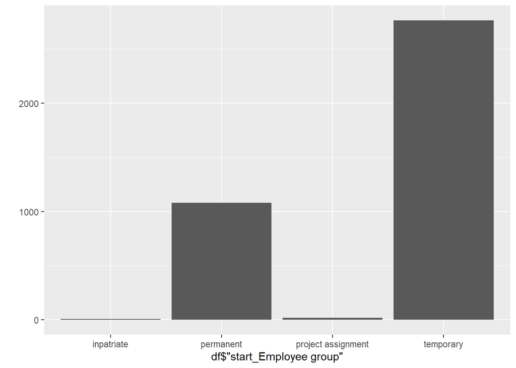

```r
qplot(df$'start_Employee group')
```

```r
df$'start_Employee group' <- NULL
```

### Cost Center

Dieses Merkmal beschreibt die Kostenstelle der Person zum letzten aktiven Zeitpunkt.

```r
# unique(df$'Cost Center')
summary(df$'Cost Center')
```

```
##    Length     Class      Mode
##      3869 character character
```

```r
sum(is.na(df$'Cost Center'))
```

```
## [1] 0
```

```r
# qplot(df$'Cost Center')
```

Wie oben bereits erläutert hat die Kostenstelle keinen Einfluss auf die Mitarbeiter, da dies intern geschieht und mögliche Zusammenhänge kausal ausgeschlossen sind, werden wir dieses Merkmal nicht weiter berücksichtigen

```r
df$`Cost Center` <- NULL
```

### decrease_Category

Funktionsbereich beim Verlassen des Unternehmens

```r
unique(df$'decrease_Category')
```

```
##  [1] "Supplier & Reporting"      "Human Resources GBS"
##  [3] "People"                    "Customer"
##  [5] "GTU GD"                    "GB Management"
##  [7] NA                          "Planning & Development"
##  [9] "IT Service CC"             "Safety"
## [11] "Procurement Services - GP" "GBR/N"
## [13] "Intellectual Property"     "RAA/A Competence"
```

```r
summary(df$'decrease_Category')
```

```
##    Length     Class      Mode
##      3869 character character
```

```r
sum(is.na(df$'decrease_Category'))
```

```
## [1] 47
```

```r
#qplot(df$'decrease_Category')

df$'decrease_Category' <- as.factor(df$'decrease_Category')
```

### decrease_Sub-category

Abteilung beim Verlassen des Unternehmens

```r
unique(df$'decrease_Sub-category')
```

```
##  [1] "VP Book to Report"          "VP Purchase to Pay"
##  [3] "Local HR"                   "HR Services LU"
##  [5] "VP Order to Cash"           "VP Personnel Services"
##  [7] "HR Services Europe"         "GTU - GD"
##  [9] "Talent Aquisition"          "HR Services German Group"
## [11] "People Services"            "GBE Management"
## [13] NA                           "GB Build"
## [15] "GTU - GB"                   "Local Controlling"
## [17] "Projects"                   "IT Ongoing"
## [19] "Product Safety Services"    "Communication"
## [21] "AP Services"                "Procurement Services - GP"
## [23] "GBR/N"                      "Supplier & Reporting Other"
## [25] "HR Service Delivery"        "Intellectual Property"
```

```r
summary(df$'decrease_Sub-category')
```

```
##    Length     Class      Mode
##      3869 character character
```

```r
sum(is.na(df$'decrease_Sub-category'))
```

```
## [1] 49
```

```r
# qplot(df$'decrease_Sub-category')

df$'decrease_Sub-category' <- NULL
```

### decrease_SDU Name for ExR

Offizieller Name der Abteilung beim Verlassen des Unternehmens

```r
unique(df$'decrease_SDU Name for ExR')
```

```
##  [1] "B2R-Financial Reporting"        "Accounts Payable"
##  [3] "Local HR"                       "HR Services Campus LU"
##  [5] "Accounts Receivable"            "Management"
##  [7] "HR Services Europe"             "IT Ongoing and Project"
##  [9] NA                               "Talent Management"
## [11] "HR Services German Group Co."   "People Services"
## [13] "Sales Tax Settlement"           "B2R-Business Reporting I"
## [15] "Cash Management & Master Data"  "GB Build"
## [17] "GSSO Technology Unit"           "Local Controlling"
## [19] "Project Finance"                "Procurement Services - GB part"
## [21] "Learning"                       "B2R-Business Reporting II"
## [23] "Business Experts"               "Ludwigshafen"
## [25] "Product Safety Services"        "Communications"
## [27] "HR Business Support"            "Agricultural Solutions"
## [29] "Global Indirect Procurement"    "Management Assistants"
## [31] "Projects HR"                    "Local Procurement"
## [33] "Digital Excellence"             "Real Estate Management"
## [35] "Intellectual Property"
```

```r
summary(df$'decrease_SDU Name for ExR')
```

```
##    Length     Class      Mode
##      3869 character character
```

```r
sum(is.na(df$'decrease_SDU Name for ExR'))
```

```
## [1] 402
```

```r
# qplot(df$'decrease_SDU Name for ExR')

df$'decrease_SDU Name for ExR' <- NULL
```

### decrease_SDU

Interner Name/Abkürzung der Abteilung beim Verlassen des Unternehmens

```r
unique(df$'decrease_SDU')
```

```
##  [1] "GBE/SB-RR"
##  [2] "GBE/SL-P"
##  [3] "GB/H LHR"
##  [4] "GBE/SHV-L"
##  [5] "GBE/SO-A"
##  [6] "GBE/SHV"
##  [7] "GBE/SHV-E"
##  [8] "GD/X_GTU"
##  [9] "GBE/SB-RM"
## [10] "GBE/SHV-T"
## [11] "GBE/SHV-G"
## [12] "GBE/SHV-P"
## [13] "GBE"
## [14] NA
## [15] "GBE/SO-V"
```

[output cut: 34 more lines]

```r
summary(df$'decrease_SDU')
```

```
##    Length     Class      Mode
##      3869 character character
```

```r
sum(is.na(df$'decrease_SDU'))
```

```
## [1] 47
```

```r
df$decrease_SDU <- NULL
```

### decrease_Service Stream

Fachbereich beim verlassen des Unternehmens.

```r
unique(df$'decrease_Service Stream')
```

```
##  [1] "B2R"                   "P2P"                   "HR Services"
##  [4] "O2C"                   "IT"                    "-"
##  [7] NA                      "OD"                    "Controlling Services"
## [10] "FEP/S"                 "Finance Services"      "S2C"
## [13] "Intellectual Property"
```

```r
summary(df$'decrease_Service Stream')
```

```
##    Length     Class      Mode
##      3869 character character
```

```r
sum(is.na(df$'decrease_Service Stream'))
```

```
## [1] 53
```

```r
# qplot(df$'decrease_Service Stream')

df$'decrease_Service Stream' <- NULL
```

### start_Category

Fachbereich in dem der Mitarbeiter anfangs eingestellt wurde. Das Quellsystem ist erst Zeit Oktober 2006 im Einsatz. Alle Mitarbeiter, die vorher begonnen haben, werden nicht berücksichtigt. Aus diesem Grund müssen diese (NaN) aus dem Datenset entfernt werden. Da es 895 dieser Fälle gibt, wird dieses Merkmal als Ganzes nicht weiter betrachet.

```r
unique(df$'start_Category')
```

```
##  [1] NA                          "Supplier & Reporting"
##  [3] "GTU GD"                    "People"
##  [5] "Customer"                  "Planning & Development"
##  [7] "GBR/N"                     "Human Resources GBS"
##  [9] "IT Service CC"             "Procurement Services - GP"
## [11] "Safety"                    "GB Management"
## [13] "Intellectual Property"     "RAA/A Competence"
## [15] "GBI_"
```

```r
summary(df$'start_Category')
```

```
##    Length     Class      Mode
##      3869 character character
```

```r
sum(is.na(df$'start_Category'))
```

```
## [1] 895
```

```r
# qplot(df$'start_Category')

df$start_Category <- NULL
#df$'start_Category' <- as.factor(df$'start_Category')
```

### start_Sub-category

Abteilung in dem der Mitarbeiter anfangs eingestellt wurde.

```r
unique(df$'start_Sub-category')
```

```
##  [1] NA                           "VP Purchase to Pay"
##  [3] "GTU - GD"                   "Talent Aquisition"
##  [5] "HR Services German Group"   "People Services"
##  [7] "VP Book to Report"          "VP Order to Cash"
##  [9] "GTU - GB"                   "HR Services Europe"
## [11] "GBR/N"                      "Projects"
## [13] "Communication"              "Local HR"
## [15] "IT Ongoing"                 "Procurement Services - GP"
## [17] "Local Controlling"          "Supplier & Reporting Other"
## [19] "HR Services LU"             "Product Safety Services"
## [21] "GBE Management"             "VP Personnel Services"
## [23] "HR Service Delivery"        "AP Services"
## [25] "Intellectual Property"      "Supply Chain"
## [27] "GB Build"                   "GBI_"
```

```r
summary(df$'start_Sub-category')
```

```
##    Length     Class      Mode
##      3869 character character
```

```r
sum(is.na(df$'start_Sub-category'))
```

```
## [1] 897
```

```r
# qplot(df$'start_Sub-category')

df$'start_Sub-category' <- NULL
```

### start_SDU Name for ExR

Offizieller Name der Abteilung beim Eintritt in das Unternehmen.

```r
unique(df$'start_SDU Name for ExR')
```

```
##  [1] NA                               "Accounts Payable"
##  [3] "IT Ongoing and Project"         "Talent Management"
##  [5] "Learning"                       "People Services"
##  [7] "B2R-Business Reporting I"       "HR Services German Group Co."
##  [9] "B2R-Business Reporting II"      "Ludwigshafen"
## [11] "Procurement Services - GB part" "Cash Management & Master Data"
## [13] "Accounts Receivable"            "Business Experts"
## [15] "B2R-Financial Reporting"        "HR Services Europe"
## [17] "Project Finance"                "Communications"
## [19] "Sales Tax Settlement"           "GSSO Technology Unit"
## [21] "Local HR"                       "Global Indirect Procurement"
## [23] "Local Controlling"              "Management Assistants"
## [25] "HR Services Campus LU"          "Management"
## [27] "Product Safety Services"        "HR Business Support"
## [29] "Real Estate Management"         "Agricultural Solutions"
## [31] "Intellectual Property"          "Supply Chain"
## [33] "GB Build"
```

```r
summary(df$'start_SDU Name for ExR')
```

```
##    Length     Class      Mode
##      3869 character character
```

```r
sum(is.na(df$'start_SDU Name for ExR'))
```

```
## [1] 1001
```

```r
# qplot(df$'start_SDU Name for ExR')

df$'start_SDU Name for ExR' <- NULL
```

### start_SDU

Interner Name der Abteilung beim Eintritt in das Unternehmen.

```r
unique(df$'start_SDU')
```

```
##  [1] NA
##  [2] "GBE/SL-P"
##  [3] "GD/X_GTU"
##  [4] "GBE/SHV-T"
##  [5] "GBE/SHV-G"
##  [6] "GBE/SHV-P"
##  [7] "GBE/SB-RM"
##  [8] "GBR/P"
##  [9] "GBE/SL-B"
## [10] "GBE/SO-B"
## [11] "GBE/SO-A"
## [12] "GB/C_GTU"
## [13] "GBE/SB-RR"
## [14] "GBE/SHV-E"
## [15] "GBR"
```

[output cut: 33 more lines]

```r
summary(df$'start_SDU')
```

```
##    Length     Class      Mode
##      3869 character character
```

```r
sum(is.na(df$'start_SDU'))
```

```
## [1] 895
```

```r
df$start_SDU <- NULL
```

### start_Service Stream

Fachbereich beim Eintritt in das Unternehmen.

```r
unique(df$'start_Service Stream')
```

```
##  [1] NA                      "P2P"                   "IT"
##  [4] "HR Services"           "B2R"                   "O2C"
##  [7] "-"                     "Controlling Services"  "OD"
## [10] "S2C"                   "FEP/S"                 "Finance Services"
## [13] "Intellectual Property"
```

```r
summary(df$'start_Service Stream')
```

```
##    Length     Class      Mode
##      3869 character character
```

```r
sum(is.na(df$'start_Service Stream'))
```

```
## [1] 919
```

```r
# qplot(df$'start_Service Stream')

df$'start_Service Stream' <- NULL
```

### Age

Dies ist das selbst berechnete Merkmal, welches das aktuelle Alter aller aktiven Mitarbeiter oder das Alter der Mitarbeiter bei Ihrem Ausstieg in Jahren anzeigt.

```r
unique(df$Age)
```

```
##  [1] 39 37 61 48 40 46 50 45 42 43 44 54 38 34 36 63 49 67 52 51 60 41 56 33 57
## [26] 68 65 59 62 53 58 47 66 55 32 64 31 30 29 35 27 28 26 25 23 22 24 20 21 19
## [51] 18
```

```r
summary(df$Age)
```

```
##    Min. 1st Qu.  Median    Mean 3rd Qu.    Max.
##   18.00   29.00   33.00   34.34   38.00   68.00
```

```r
sum(is.na(df$Age))
```

```
## [1] 0
```

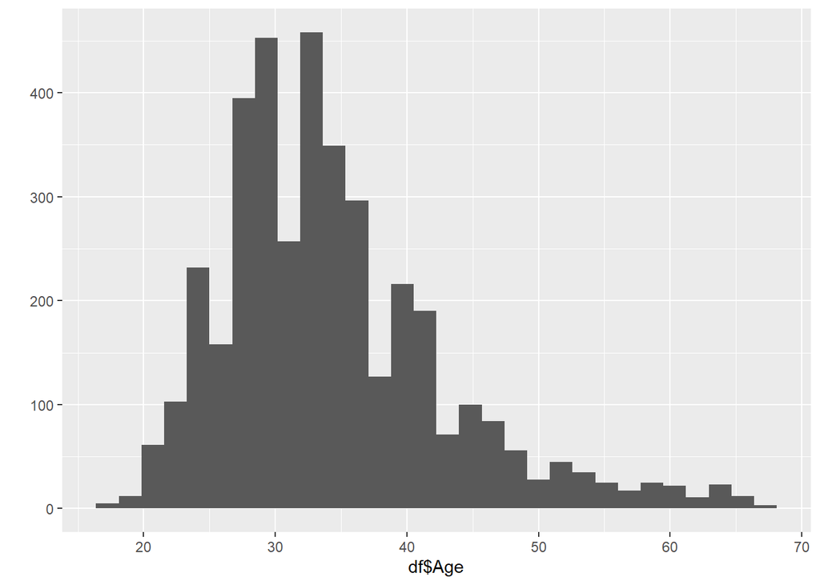

```r
qplot(df$Age)
```

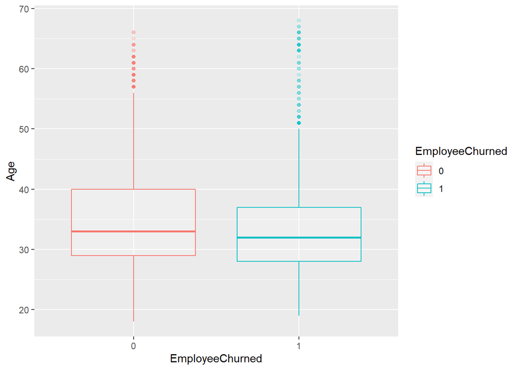

```r
ggplot(df, aes(EmployeeChurned, Age)) +
  geom_boxplot(aes(colour = EmployeeChurned), alpha=0.2)
```

```r
summary(df$`Month Of Service`)
```

```
##    Min. 1st Qu.  Median    Mean 3rd Qu.    Max.
##   -5.00    9.00   26.00   43.07   57.00  183.00
```

```r
sum(is.na(df$`Month Of Service`))
```

```
## [1] 0
```

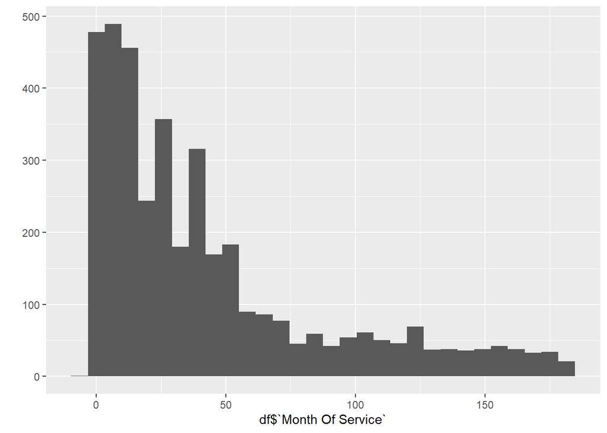

```r
#Bei der Berechnung wurden bereits alle "NA"-Werte gelöscht, daher sind diese hier nicht mehr vorhanden.

qplot(df$`Month Of Service`)
```

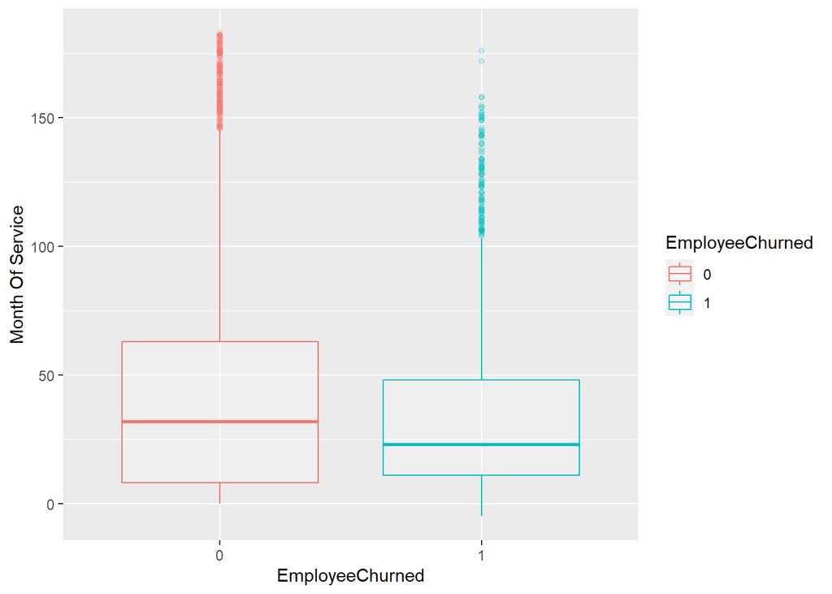

```r
ggplot(df, aes(EmployeeChurned, `Month Of Service`)) +
  geom_boxplot(aes(colour = EmployeeChurned), alpha=0.2)
```

Es lässt sich erkennen, dass Mitarbeitende mit längerer Anstellungszeit eher im Unternehmen bleiben, als weniger lang angestellte Mitarbeitende.

### Month Since Last Development

Das hier von uns erzeugte und gezeigte Merkmal beschreibt die Dauer zwischen der letzten Beförderung und dem Austritt aus dem Unternehmen. Sollte der Mitarbeiter noch aktiv sein, bezieht sich die Dauer auf die letzte Beförderung und das aktuelle Datum. Hier gibt es falsche Werte. Diese sind negative Zeiten. Diese falschen Werte sind entstanden, wenn ein Mitarbeiter eine Beförderung erhalten, danach das Unternhemen verlassen und später wieder in das Unternehmen als Mitarbeiter aufgenommen wurde. Diese falschen Werte ersetzten wir durch 0.

```r
#ändert alle negativen Werte in 0
df$`Months Since Last Development` <- pmax(df$`Months Since Last Development`, 0)

summary(df$`Months Since Last Development`)
```

```
##    Min. 1st Qu.  Median    Mean 3rd Qu.    Max.
##    0.00    5.00   15.00   26.33   36.00  183.00
```

```r
sum(is.na(df$`Months Since Last Development`))
```

```
## [1] 0
```

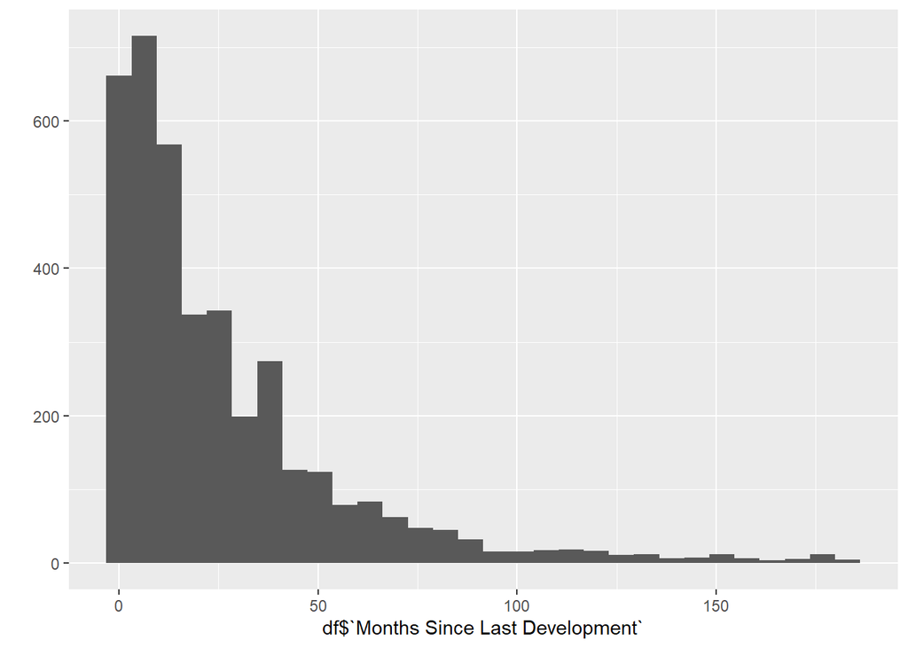

```r
qplot(df$`Months Since Last Development`)
```

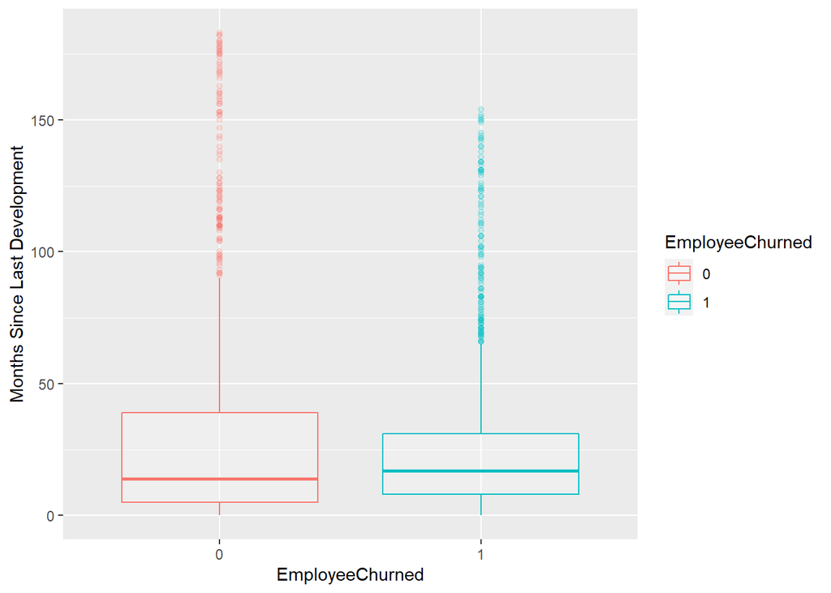

```r
ggplot(df, aes(EmployeeChurned, `Months Since Last Development`)) +
  geom_boxplot(aes(colour = EmployeeChurned), alpha=0.2)
```

Auf den ersten Blick gibt es keinen erkennbaren Zusammenhang zwischen der Zielvariable EmployeeChurned und Month Since Last Development.

### Korrelation der Numerischen Merkmale

Die roten Punkte bedeuten, dass der Mitarbeiter nicht mehr im Unternehmen ist.

```r
str(df)
```

```
## tibble [3,869 x 19] (S3: tbl_df/tbl/data.frame)
##  $ Gender                          : chr [1:3869] "1" "0" "1" "1" ...
##  $ Part Time Mark                  : chr [1:3869] "1" "0" "0" "0" ...
##  $ TemporaryPersonel               : chr [1:3869] "0" "0" "0" "0" ...
##  $ development to exempt           : chr [1:3869] "1" "0" "1" "1" ...
##  $ Vertical_Horizontal_Developments: Factor w/ 3 levels ">= 3","0","1-2": 1 3 2 3 3 2 3 3 3 3 ...
##  $ start_Calendar Year/Month       : Date[1:3869], format: "2009-10-01" "2008-05-01" ...
##  $ start_contract type             : Factor w/ 3 levels "apprentice","permanent staff",..: 2 3 2 2 3 2 2 2 2 2 ...
##  $ start_Part time mark            : chr [1:3869] "0" "1" "0" "0" ...
##  $ LastActive_Calendar Year/Month  : Date[1:3869], format: "2021-10-01" "2016-06-01" ...
##  $ EmployeeChurned                 : chr [1:3869] "0" "1" "1" "0" ...
##  $ start_Cost center               : chr [1:3869] "DB152100" "DB67100" "DB67500" "DB610306" ...
##  $ decrease_Category               : Factor w/ 13 levels "Customer","GB Management",..: 13 13 5 8 13 1 8 8 13 13 ...
##  $ Nationality_Classification      : Factor w/ 3 levels "EU","German",..: 2 3 2 2 2 2 2 2 2 1 ...
##  $ Month Of Service                : num [1:3869] 146 98 151 60 39 163 130 53 32 114 ...
##  $ Age                             : num [1:3869] 39 37 61 39 48 40 46 37 61 46 ...
##  $ Months Since Last Development   : num [1:3869] 3 18 41 71 14 163 81 0 32 26 ...
##  $ NonExempt                       : chr [1:3869] "0" "1" "0" "0" ...
##  $ Paybands                        : Factor w/ 8 levels "A","B","C","D",..: 7 6 5 7 3 3 8 8 7 8 ...
##  $ start_NonExempt                 : chr [1:3869] "1" "1" "1" "1" ...
```

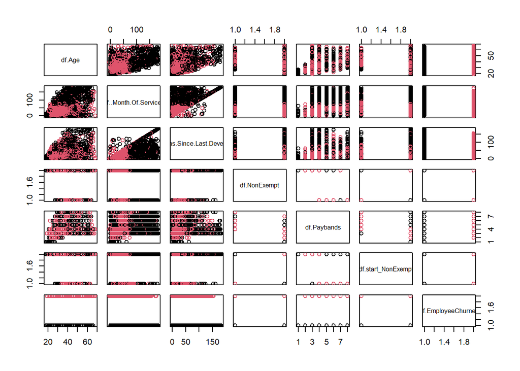

```r
df$EmployeeChurned <- as.factor(df$EmployeeChurned)
df_cor <- data.frame(df$Age, df$`Month Of Service`, df$`Months Since Last Development`, df$NonExempt, df$Paybands, df$start_NonExempt,  df$EmployeeChurned)
df_cor$df.NonExempt <- as.factor(df_cor$df.NonExempt)
df_cor$df.start_NonExempt <- as.factor(df_cor$df.start_NonExempt)
pairs(df_cor, col = df_cor$df.EmployeeChurned)
```

Im nächsten Schritt wird beispielhaft versucht, Zusammenhänge zwischen verschiedenen Merkmalen und der Abwanderung zu Visualisieren.

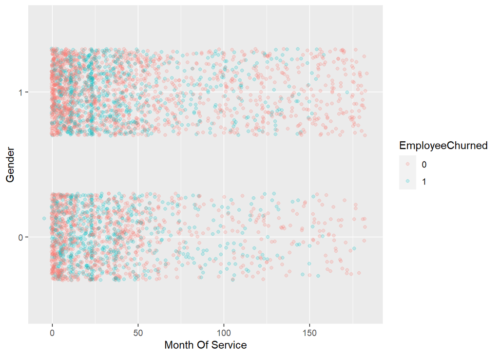

```r
# df$Gender <- as.factor(df$Gender)
ggplot(df, aes(`Month Of Service`, Gender)) +
geom_jitter(aes(colour = EmployeeChurned), alpha=0.2, height = 0.3)
```

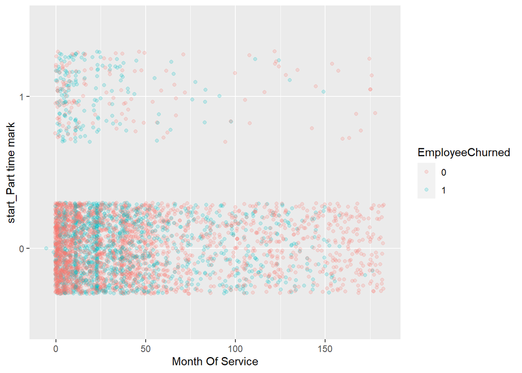

```r
ggplot(df, aes(`Month Of Service`, `start_Part time mark`)) +
geom_jitter(aes(colour = EmployeeChurned), alpha=0.2, height = 0.3)
```

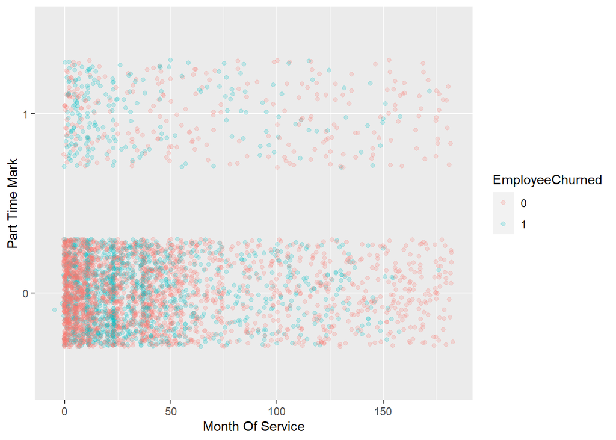

```r
ggplot(df, aes(`Month Of Service`, `Part Time Mark`)) +
geom_jitter(aes(colour = EmployeeChurned), alpha=0.2, height = 0.3)
```

```r
names(df)
```

```
##  [1] "Gender"                           "Part Time Mark"
##  [3] "TemporaryPersonel"                "development to exempt"
##  [5] "Vertical_Horizontal_Developments" "start_Calendar Year/Month"
##  [7] "start_contract type"              "start_Part time mark"
##  [9] "LastActive_Calendar Year/Month"   "EmployeeChurned"
## [11] "start_Cost center"                "decrease_Category"
## [13] "Nationality_Classification"       "Month Of Service"
## [15] "Age"                              "Months Since Last Development"
## [17] "NonExempt"                        "Paybands"
## [19] "start_NonExempt"
```

```r
str(df)
```

```
## tibble [3,869 x 19] (S3: tbl_df/tbl/data.frame)
##  $ Gender                          : chr [1:3869] "1" "0" "1" "1" ...
##  $ Part Time Mark                  : chr [1:3869] "1" "0" "0" "0" ...
##  $ TemporaryPersonel               : chr [1:3869] "0" "0" "0" "0" ...
##  $ development to exempt           : chr [1:3869] "1" "0" "1" "1" ...
##  $ Vertical_Horizontal_Developments: Factor w/ 3 levels ">= 3","0","1-2": 1 3 2 3 3 2 3 3 3 3 ...
##  $ start_Calendar Year/Month       : Date[1:3869], format: "2009-10-01" "2008-05-01" ...
##  $ start_contract type             : Factor w/ 3 levels "apprentice","permanent staff",..: 2 3 2 2 3 2 2 2 2 2 ...
##  $ start_Part time mark            : chr [1:3869] "0" "1" "0" "0" ...
##  $ LastActive_Calendar Year/Month  : Date[1:3869], format: "2021-10-01" "2016-06-01" ...
##  $ EmployeeChurned                 : Factor w/ 2 levels "0","1": 1 2 2 1 1 1 2 2 1 2 ...
##  $ start_Cost center               : chr [1:3869] "DB152100" "DB67100" "DB67500" "DB610306" ...
##  $ decrease_Category               : Factor w/ 13 levels "Customer","GB Management",..: 13 13 5 8 13 1 8 8 13 13 ...
##  $ Nationality_Classification      : Factor w/ 3 levels "EU","German",..: 2 3 2 2 2 2 2 2 2 1 ...
##  $ Month Of Service                : num [1:3869] 146 98 151 60 39 163 130 53 32 114 ...
##  $ Age                             : num [1:3869] 39 37 61 39 48 40 46 37 61 46 ...
##  $ Months Since Last Development   : num [1:3869] 3 18 41 71 14 163 81 0 32 26 ...
##  $ NonExempt                       : chr [1:3869] "0" "1" "0" "0" ...
##  $ Paybands                        : Factor w/ 8 levels "A","B","C","D",..: 7 6 5 7 3 3 8 8 7 8 ...
##  $ start_NonExempt                 : chr [1:3869] "1" "1" "1" "1" ...
```

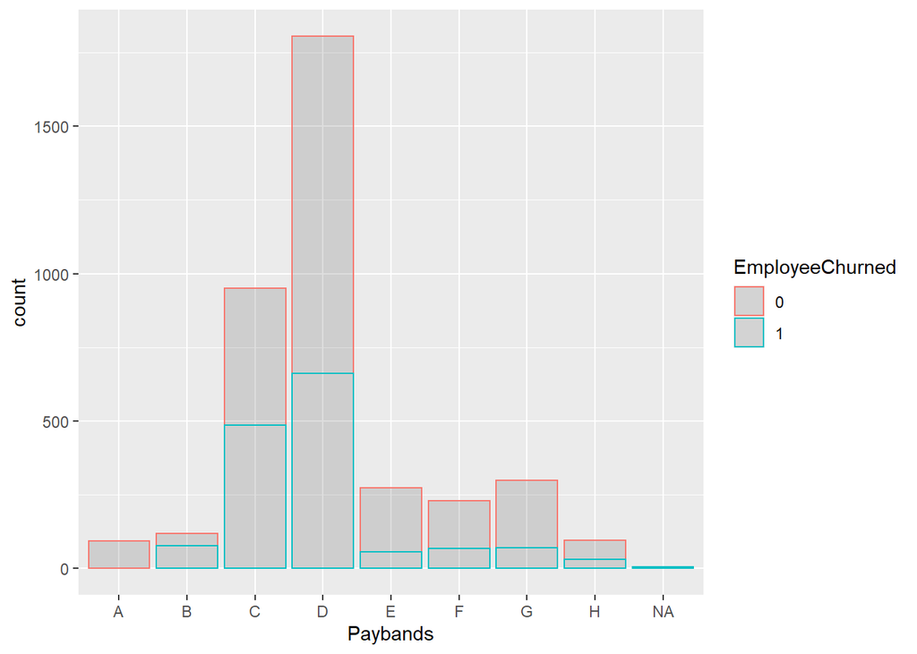

```r
ggplot(df, aes(Paybands)) +
  geom_bar(aes(colour = EmployeeChurned), alpha=0.2)
```

Fokus auf Paybands “C” und “D”, da hohe Zahl an Mitarbeitenden sowie Mitarbeiterabwanderung. Speziell das Payband “C” weißt eine hohe Mitarbeiterabwanderung auf.

Das Payband “A” umfasst die Auszubildenden, von denen laut der Daten keiner das Unternehmen während der Ausbildung verlassen hat.

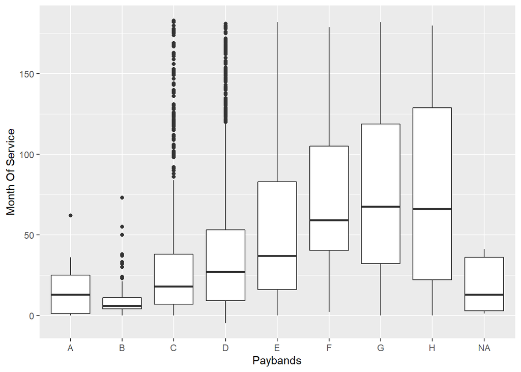

```r
ggplot(df, aes(Paybands, `Month Of Service`)) +
  geom_boxplot()
```

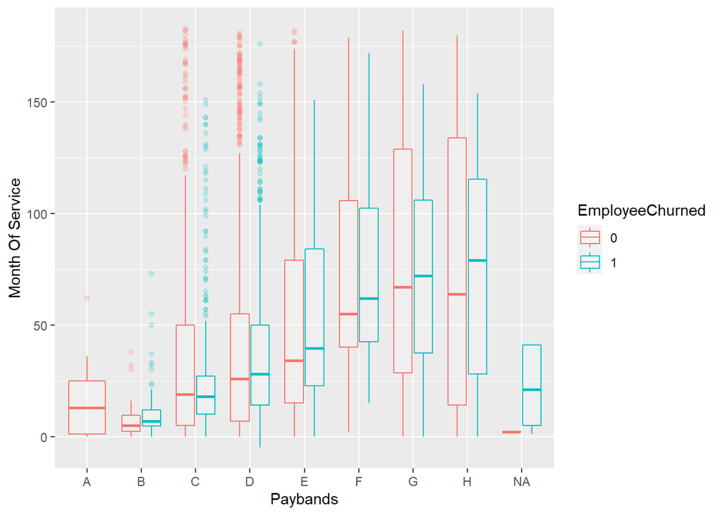

```r
ggplot(df, aes(Paybands, `Month Of Service`)) +
  geom_boxplot(aes(colour = EmployeeChurned), alpha=0.2)
```

Mitarbeitende in höheren Paybands zum Zeitpunkt der letzten Aktivität sind länger im Unternehmen, als in unteren. Mitarbeitende, die das Unternehmen verlassen haben, waren in fast allen Paybands länger im Unternehmen als die aktiven. Dies kann auch daran liegen, dass solche Positionen auch nachbesetzt werden müssen, zum Teil von extern oder es rücken Mitarbeitende nach.

```r
write_xlsx(df,"20220110_dataPrepped_beforeOneHot.xlsx")
```

## Umwandeln qualitativer Merkmal in für die algorithmen lesbare dichotome Merkmale (0 und 1).

```r
hot_df <- one_hot(as.data.table(df))
write_xlsx(hot_df,"20220110_dataPrepped_afterOneHot.xlsx")

str(hot_df)
```

```
## Classes 'data.table' and 'data.frame':   3869 obs. of  45 variables:
##  $ Gender                                     : chr  "1" "0" "1" "1" ...
##  $ Part Time Mark                             : chr  "1" "0" "0" "0" ...
##  $ TemporaryPersonel                          : chr  "0" "0" "0" "0" ...
##  $ development to exempt                      : chr  "1" "0" "1" "1" ...
##  $ Vertical_Horizontal_Developments_>= 3      : int  1 0 0 0 0 0 0 0 0 0 ...
##  $ Vertical_Horizontal_Developments_0         : int  0 0 1 0 0 1 0 0 0 0 ...
##  $ Vertical_Horizontal_Developments_1-2       : int  0 1 0 1 1 0 1 1 1 1 ...
##  $ start_Calendar Year/Month                  : Date, format: "2009-10-01" "2008-05-01" ...
##  $ start_contract type_apprentice             : int  0 0 0 0 0 0 0 0 0 0 ...
##  $ start_contract type_permanent staff        : int  1 0 1 1 0 1 1 1 1 1 ...
##  $ start_contract type_temporary personnel    : int  0 1 0 0 1 0 0 0 0 0 ...
##  $ start_Part time mark                       : chr  "0" "1" "0" "0" ...
##  $ LastActive_Calendar Year/Month             : Date, format: "2021-10-01" "2016-06-01" ...
##  $ EmployeeChurned_0                          : int  1 0 0 1 1 1 0 0 1 0 ...
```

[output cut: 32 more lines]